# 06 · Q4 Pulse 3: how people write health-advice messages to AI

Message length, style, and chat length in the pasted AI health conversations

Denicia Aragon Espinosa

November 06, 2026

## Key findings

- **The sample:** 59 participants pasted an AI health conversation. Together they hold 141 participant messages and 149 AI turns. 7 pastes held only the AI’s side, with no participant messages.
- **Most health messages were short.** The median message was **15 words**, and the middle half ran from 7 to 32 words. **64%** were 20 words or fewer. A smaller group wrote long messages, often with symptoms or test results pasted in.
- **Messages were often not written as formal questions.** **28%** had a question mark, and **21%** started with a lowercase letter.
- **Chats were short.** The median chat had **2 participant messages**, and the median first message was **18.5 words**. **62%** of chats had 2 or more participant messages (multi-turn); the rest asked once.
- **The AI said much more than the person.** The median AI reply was **277.5 words**. In a typical exchange, the AI reply was **16.2 times** as long as the message it answered, and **95%** of replies were longer than the message.

**Things to keep in mind**

- **Small sample.** This is 59 people (52 with participant messages), so percentages can move by several points if a few people differ.
- **Exclusions.** 1 participant was left out because their paste was not a personal health conversation: it was a homework assignment (the AI summarised a CDC section on child development and wrote a class discussion post). Their rows stay in the step 05 data with `exclude = TRUE`; this report keeps only rows where `exclude` is FALSE. The full list, with reasons, is in `output/05_build-conversation-dataset/05_exclusions.csv`.
- **Pasted, past chats.** Participants pasted a past conversation of their own, so we only see what they chose to paste.
- **Line breaks were lost.** The survey export removed line breaks; 2 or more spaces in a row mark where they were. So the “starts lowercase” check looks at the first character that isn’t a space.

## Data

The input is the corrected long-format file from step 05: one row per turn (one message by one speaker). Participant messages are the `human_*` turns. AI text pasted before the participant’s first message (`ai_0`) is not a reply to a message, so it is left out of the AI-reply section. Participants flagged `exclude = TRUE` in step 05 are dropped first (see *Things to keep in mind*).

```r
long_path <- here::here("data", "processed", "05_Q4_3_conversations_long.csv")
log_input(long_path)

turns_all <- read_csv(long_path, show_col_types = FALSE,
                      col_select = c(prolific_pid, exclude, exclude_reason, speaker, turn_label,
                                     turn_num, exchange_num, text, n_words))

# Exclusions: step 05 flags (but keeps) participants whose paste should not be analysed.
# Here we keep only the rows where exclude is FALSE.
n_excluded <- n_distinct(turns_all$prolific_pid[turns_all$exclude])
turns <- turns_all |> filter(!exclude) |> select(-exclude, -exclude_reason)

# Count words again here (any run of non-space characters = 1 word) and check it
# matches the n_words column made in step 05.
turns <- turns |> mutate(words = str_count(text, "\\S+"))
stopifnot(all(turns$words == turns$n_words))

n_people <- n_distinct(turns$prolific_pid)
n_turns  <- nrow(turns)
n_msgs   <- sum(turns$speaker == "human")
n_ai     <- sum(turns$speaker == "ai")

# Helper for printing proportions as whole-number percentages
pct <- function(x) percent(x, accuracy = 1)
```

```r
sample_tbl <- tibble(
  what  = c("Participants (after exclusions)", "Participants excluded", "Turns (all)",
            "Participant messages (human turns)",
            "AI turns (all)", "AI turns before the first message (ai_0)",
            "Participants with no messages (AI-only pastes)"),
  count = c(n_people, n_excluded, n_turns, n_msgs, n_ai,
            sum(turns$turn_label == "ai_0"),
            n_people - n_distinct(turns$prolific_pid[turns$speaker == "human"]))
)
save_table(sample_tbl, "sample")
knitr::kable(sample_tbl, col.names = c("", "Count"))
```

|  | Count |
| --- | --- |
| Participants (after exclusions) | 59 |
| Participants excluded | 1 |
| Turns (all) | 290 |
| Participant messages (human turns) | 141 |
| AI turns (all) | 149 |
| AI turns before the first message (ai_0) | 9 |
| Participants with no messages (AI-only pastes) | 7 |

## 1. What a participant message looks like

For every participant message we count the words and check three simple style markers:

- **20 words or fewer:** a short message.
- **Starts with a lowercase letter:** casual typing, as in “what does this mean”. We look at the first character that isn’t a space.
- **Contains a “?”:** written as a question.

```r
msgs <- turns |>
  filter(speaker == "human") |>
  mutate(
    first_char       = str_sub(str_trim(text), 1, 1),
    lowercase_start  = str_detect(first_char, "[[:lower:]]"),
    has_question     = str_detect(text, fixed("?")),
    short_20         = words <= 20
  )

msg_stats <- msgs |>
  summarise(
    n_messages          = n(),
    median_words        = median(words),
    q1_words            = quantile(words, 0.25),
    q3_words            = quantile(words, 0.75),
    pct_20_or_fewer     = mean(short_20),
    pct_lowercase_start = mean(lowercase_start),
    pct_question_mark   = mean(has_question)
  )
```

```r
msg_tbl <- tibble(
  measure = c("Median words per message", "Middle half of messages (IQR)",
              "Messages of 20 words or fewer", "Messages starting in lowercase",
              "Messages with a question mark"),
  value = c(msg_stats$median_words,
            paste0(msg_stats$q1_words, " to ", msg_stats$q3_words, " words"),
            pct(msg_stats$pct_20_or_fewer), pct(msg_stats$pct_lowercase_start),
            pct(msg_stats$pct_question_mark))
)
save_table(msg_stats, "message-stats")
knitr::kable(msg_tbl, col.names = c("", paste0("Health messages (n = ", msg_stats$n_messages, ")")))
```

|  | Health messages (n = 141) |
| --- | --- |
| Median words per message | 15 |
| Middle half of messages (IQR) | 7 to 32 words |
| Messages of 20 words or fewer | 64% |
| Messages starting in lowercase | 21% |
| Messages with a question mark | 28% |

**How to read this:** the median is the middle message when all messages are sorted by length, so half are shorter and half are longer. The IQR is the range covering the middle half of messages. A few very long messages (for example, pasted test results) don’t pull the median up the way they would pull up an average.

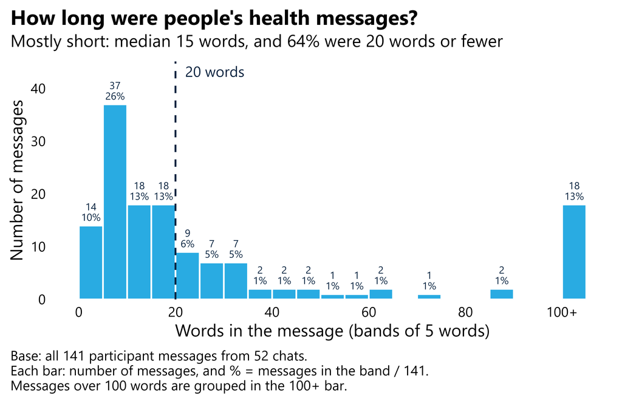

```r
cap <- 100   # messages longer than this go into one "100+" bar so the chart stays readable
n_m <- msg_stats$n_messages
hist_lab <- msgs |>
  mutate(mid = floor(pmin(words, cap + 1) / 5) * 5 + 2.5) |>
  count(mid) |>
  mutate(lab = paste0(n, "\n", round(100 * n / n_m), "%"))
p_hist <- msgs |>
  mutate(words_capped = pmin(words, cap + 1)) |>
  ggplot(aes(words_capped)) +
  geom_histogram(binwidth = 5, boundary = 0, closed = "left",
                 fill = speaker_cols["Participant"], color = "white") +
  geom_vline(xintercept = 20, linetype = "dashed", linewidth = 1, color = project_colors["charcoal"]) +
  # n and % printed on each bar (empty bars get no label)
  geom_label(data = hist_lab, aes(x = mid, y = n, label = lab), inherit.aes = FALSE,
             fill = "white", label.size = 0, border.colour = NA, label.padding = unit(0.05, "lines"),
             vjust = -0.1, size = 4.2, lineheight = 0.85, color = project_colors["charcoal"]) +
  annotate("text", x = 22, y = Inf, vjust = 1.5, hjust = 0, size = 6,
           label = "20 words", color = project_colors["charcoal"]) +
  scale_x_continuous(breaks = c(0, 20, 40, 60, 80, cap), labels = c(0, 20, 40, 60, 80, paste0(cap, "+"))) +
  scale_y_continuous(expand = expansion(mult = c(0, 0.22))) +
  labs(title = "How long were people's health messages?",
       subtitle = paste0("Mostly short: median ", msg_stats$median_words, " words, and ",
                         pct(msg_stats$pct_20_or_fewer), " were 20 words or fewer"),
       x = "Words in the message (bands of 5 words)", y = "Number of messages",
       caption = paste0("Base: all ", n_m, " participant messages from ", n_distinct(msgs$prolific_pid),
                        " chats.\nEach bar: number of messages, and % = messages in the band / ", n_m, ".\n",
                        "Messages over ", cap, " words are grouped in the 100+ bar."))
p_hist
```

```r
save_fig("message-word-count-histogram", p_hist, width = 11, height = 7)
```

## 2. How long the chats were

Here each participant’s pasted conversation is one chat. We count the participant messages in it, look at the length of the first message, and count a chat as **multi-turn** if the person sent 2 or more messages.

```r
chats <- turns |>
  group_by(prolific_pid) |>
  summarise(
    n_messages  = sum(speaker == "human"),
    first_words = words[turn_label == "human_1"][1]   # NA for AI-only pastes
  ) |>
  ungroup()

chats_with_msgs <- filter(chats, n_messages > 0)

chat_stats <- chats_with_msgs |>
  summarise(
    n_chats            = n(),
    median_msgs        = median(n_messages),
    max_msgs           = max(n_messages),
    median_first_words = median(first_words),
    pct_multi_turn     = mean(n_messages >= 2)
  )
```

```r
chat_tbl <- tibble(
  measure = c("Median participant messages per chat", "Most messages in one chat",
              "Median words in the first message", "Chats with 2+ participant messages (multi-turn)"),
  value = c(chat_stats$median_msgs, chat_stats$max_msgs,
            chat_stats$median_first_words, pct(chat_stats$pct_multi_turn))
)
save_table(chat_stats, "chat-stats")
knitr::kable(chat_tbl, col.names = c("", paste0("Health chats (n = ", chat_stats$n_chats, ")")))
```

|  | Health chats (n = 52) |
| --- | --- |
| Median participant messages per chat | 2 |
| Most messages in one chat | 13 |
| Median words in the first message | 18.5 |
| Chats with 2+ participant messages (multi-turn) | 62% |

The 7 pastes that hold only the AI’s side have no participant messages, so they are left out of these numbers (they show as 0 in the chart below). Every participant message counts toward multi-turn, including short ones like “thanks”.

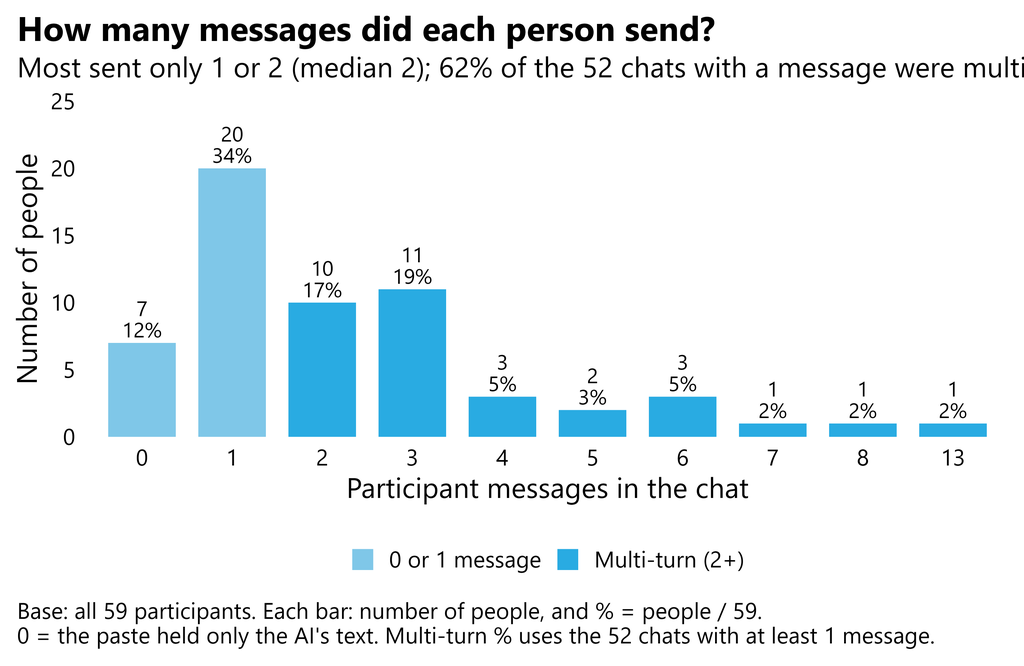

```r
msgs_per_chat <- chats |> count(n_messages)
save_table(msgs_per_chat, "messages-per-chat")

p_bar <- ggplot(msgs_per_chat, aes(factor(n_messages), n)) +
  geom_col(aes(fill = n_messages >= 2), width = 0.75) +
  geom_text(aes(label = paste0(n, "\n", round(100 * n / n_people), "%")),
            vjust = -0.15, size = 5.2, lineheight = 0.85) +
  scale_fill_manual(values = c(`FALSE` = unname(project_colors["ochre"]),
                               `TRUE`  = unname(project_colors["clay"])),
                    labels = c("0 or 1 message", "Multi-turn (2+)"), name = NULL) +
  scale_y_continuous(expand = expansion(mult = c(0, 0.25))) +
  labs(title = "How many messages did each person send?",
       subtitle = paste0("Most sent only 1 or 2 (median ", chat_stats$median_msgs, "); ",
                         pct(chat_stats$pct_multi_turn), " of the ", chat_stats$n_chats,
                         " chats with a message were multi-turn"),
       x = "Participant messages in the chat", y = "Number of people",
       caption = paste0("Base: all ", n_people, " participants. Each bar: number of people, and % = people / ",
                        n_people, ".\n0 = the paste held only the AI's text. Multi-turn % uses the ",
                        chat_stats$n_chats, " chats with at least 1 message."))
p_bar
```

```r
save_fig("messages-per-chat", p_bar, width = 11, height = 7)
```

## 3. For context: how long the AI’s replies were

We pair each participant message with the AI reply that follows it in the same exchange (`human_1` with `ai_1`, and so on). Then we divide the reply’s word count by the message’s word count. A ratio of 10 means the AI wrote 10 times as many words as the person.

```r
pairs <- turns |>
  filter(exchange_num >= 1) |>
  select(prolific_pid, exchange_num, speaker, words) |>
  pivot_wider(names_from = speaker, values_from = words) |>
  filter(!is.na(human), !is.na(ai)) |>
  mutate(ratio = ai / human)

ai_stats <- tibble(
  n_pairs          = nrow(pairs),
  median_ai_words  = median(pairs$ai),
  q1_ai_words      = quantile(pairs$ai, 0.25),
  q3_ai_words      = quantile(pairs$ai, 0.75),
  median_ratio     = round(median(pairs$ratio), 1),
  pct_ai_longer    = mean(pairs$ai > pairs$human)
)
```

```r
save_table(ai_stats, "ai-reply-stats")
knitr::kable(tibble(
  measure = c("Message-reply pairs", "Median words in an AI reply", "Middle half of AI replies (IQR)",
              "Median times longer than the message", "Replies longer than the message"),
  value   = c(ai_stats$n_pairs, ai_stats$median_ai_words,
              paste0(ai_stats$q1_ai_words, " to ", ai_stats$q3_ai_words, " words"),
              ai_stats$median_ratio, pct(ai_stats$pct_ai_longer))
), col.names = c("", "Value"))
```

|  | Value |
| --- | --- |
| Message-reply pairs | 140 |
| Median words in an AI reply | 277.5 |
| Middle half of AI replies (IQR) | 158.25 to 425.5 words |
| Median times longer than the message | 16.2 |
| Replies longer than the message | 95% |

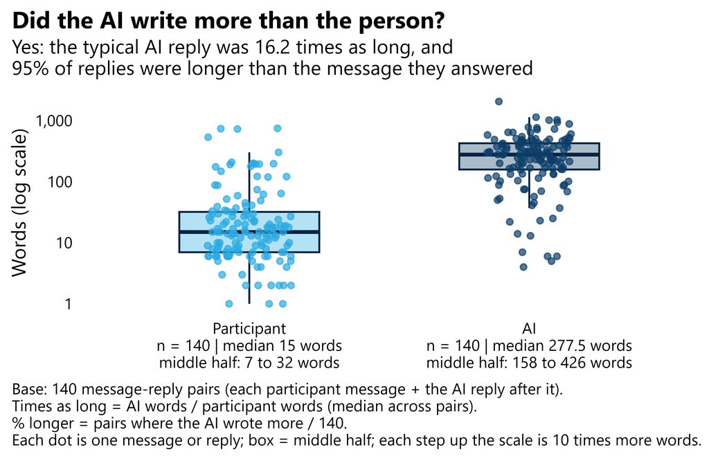

```r
lengths <- bind_rows(
  tibble(who = "Participant", words = pairs$human),
  tibble(who = "AI",          words = pairs$ai)
) |> mutate(who = factor(who, levels = c("Participant", "AI")))
medians <- lengths |> group_by(who) |>
  summarise(n = n(), median = median(words),
            q1 = round(quantile(words, 0.25)), q3 = round(quantile(words, 0.75))) |>
  mutate(label = paste0(who, "\nn = ", n, " | median ", median, " words\nmiddle half: ", q1, " to ", q3, " words"))
axis_labels <- setNames(medians$label, as.character(medians$who))

set.seed(606)   # fixed jitter so the dots land in the same place every time
p_cmp <- ggplot(lengths, aes(who, words, fill = who)) +
  geom_boxplot(width = 0.5, outlier.shape = NA, alpha = 0.35, color = project_colors["charcoal"]) +
  geom_jitter(aes(color = who), width = 0.15, height = 0, size = 2.5, alpha = 0.7) +
  scale_y_log10(labels = comma) +
  scale_x_discrete(labels = axis_labels) +
  scale_fill_manual(values = speaker_cols, guide = "none") +
  scale_color_manual(values = speaker_cols, guide = "none") +
  labs(title = "Did the AI write more than the person?",
       subtitle = paste0("Yes: the typical AI reply was ", ai_stats$median_ratio, " times as long, and\n",
                         pct(ai_stats$pct_ai_longer), " of replies were longer than the message they answered"),
       x = NULL, y = "Words (log scale)",
       caption = paste0("Base: ", ai_stats$n_pairs, " message-reply pairs (each participant message + the AI reply after it).\n",
                        "Times as long = AI words / participant words (median across pairs).\n",
                        "% longer = pairs where the AI wrote more / ", ai_stats$n_pairs, ".\n",
                        "Each dot is one message or reply; box = middle half; each step up the scale is 10 times more words."))
p_cmp
```

```r
save_fig("participant-vs-ai-length", p_cmp, width = 11, height = 7.5)
```

## Files written

All tables and figures are in `output/06_message-stats/`:

- **Tables:** `sample.csv`, `message-stats.csv`, `chat-stats.csv`, `messages-per-chat.csv`, `ai-reply-stats.csv`
- **Figures:** `message-word-count-histogram.png`, `messages-per-chat.png`, `participant-vs-ai-length.png`